# DA410_Project6_MattGraham

Principal Component Analysis (PCA)

```r
library(nnspat)  # used for dist2full()
library("dplyr")  # used to select numeric datatypes
library("ggplot2")
library(reshape)  # used for melting matricies
library(klaR)
library(ggvis)
library(class)
library(gmodels)
library(MASS)
library(readxl)
library(psych)
```

Get data

```r
beetles <- read.table("C:/mattgraham93.github.io/school/22_3_DA410/data/T5_5_FBEETLES.DAT", header=FALSE)
colnames(beetles) <- c("Experiment", 'Species', 'post_dist', 'l_elytra','len_sec_an', 'len_thi_an')

oleracea <- beetles[beetles$Species==1, -c(1:2)]  # we assume that species 1 = oleracea
carduorum <- beetles[beetles$Species==2, -c(1:2)] # we assume that species 2 = carduorum

beetles
```

| Experiment | Species | post_dist | l_elytra | len_sec_an | len_thi_an |
| --- | --- | --- | --- | --- | --- |
| 1 | 1 | 189 | 245 | 137 | 163 |
| 2 | 1 | 192 | 260 | 132 | 217 |
| 3 | 1 | 217 | 276 | 141 | 192 |
| 4 | 1 | 221 | 299 | 142 | 213 |
| 5 | 1 | 171 | 239 | 128 | 158 |
| 6 | 1 | 192 | 262 | 147 | 173 |
| 7 | 1 | 213 | 278 | 136 | 201 |
| 8 | 1 | 192 | 255 | 128 | 185 |
| 9 | 1 | 170 | 244 | 128 | 192 |
| 10 | 1 | 201 | 276 | 146 | 186 |

[output cut: 29 more lines]

## Oleracea PCA

### a. Get S and R

```r
S1 = cov(oleracea)
R1 = cor(oleracea)
```

S1

```r
as.data.frame(S1)
```

|  | post_dist | l_elytra | len_sec_an | len_thi_an |
| --- | --- | --- | --- | --- |
| post_dist | 187.59649 | 176.86257 | 48.37135 | 113.58187 |
| l_elytra | 176.86257 | 345.38596 | 75.97953 | 118.78070 |
| len_sec_an | 48.37135 | 75.97953 | 66.35673 | 16.24269 |
| len_thi_an | 113.58187 | 118.78070 | 16.24269 | 239.94152 |

R1

```r
as.data.frame(R1)
```

|  | post_dist | l_elytra | len_sec_an | len_thi_an |
| --- | --- | --- | --- | --- |
| post_dist | 1.0000000 | 0.6948183 | 0.4335442 | 0.5353576 |
| l_elytra | 0.6948183 | 1.0000000 | 0.5018822 | 0.4126110 |
| len_sec_an | 0.4335442 | 0.5018822 | 1.0000000 | 0.1287250 |
| len_thi_an | 0.5353576 | 0.4126110 | 0.1287250 | 1.0000000 |

### b. Get eigenvalues and eigenvectors of S and R

```r
eig.S1 <- eigen(S1)
eig.R1 <- eigen(R1)
```

Eigen S1

```r
eig.S1
```

```
## eigen() decomposition
## $values
## [1] 561.30574 168.98584  65.27709  43.71203
##
## $vectors
##            [,1]         [,2]       [,3]       [,4]
## [1,] -0.4997445  0.009204574  0.8230272  0.2698089
## [2,] -0.7187015 -0.484408702 -0.4778690  0.1430301
## [3,] -0.1739702 -0.220296505  0.2042647 -0.9378058
## [4,] -0.4510631  0.846600812 -0.2292234 -0.1651236
```

Eigen R1

```r
eig.R1
```

```
## eigen() decomposition
## $values
## [1] 2.3952353 0.8869271 0.4318977 0.2859399
##
## $vectors
##           [,1]       [,2]       [,3]        [,4]
## [1,] 0.5729764  0.1117770 -0.3104311  0.75022433
## [2,] 0.5617458 -0.1172002 -0.5248012 -0.62872048
## [3,] 0.4192879 -0.7000880  0.5775318  0.02305369
## [4,] 0.4246614  0.6954472  0.5428382 -0.20332864
```

### c. Percent variance explained and plot S and R

```r
for (r in eig.R1$values) {
  print(r/sum(eig.R1$values))
}
```

```
## [1] 0.5988088
## [1] 0.2217318
## [1] 0.1079744
## [1] 0.07148499
```

We can see that of our eigen values, ~60% of our variance is explained with just one dimension, while ~32% is explained with 2 and 3 dimensions. This can be seen below.

#### Plot

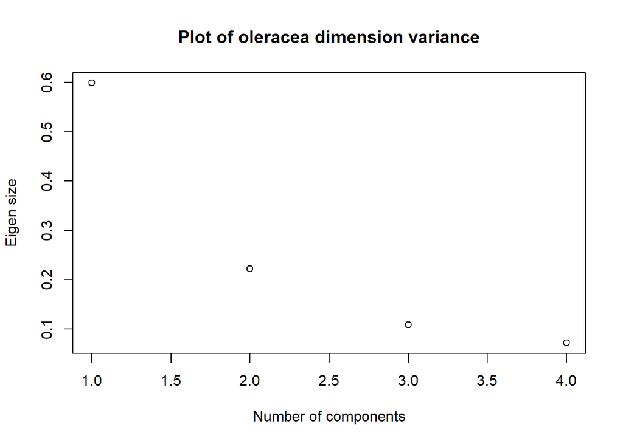

```r
plot(eig.R1$values/sum(eig.R1$values), xlab = 'Number of components', ylab='Eigen size', main='Plot of oleracea dimension variance')
```

### d. Decide compontent retention and show reasoning

Based on the percentage of total variance, it makes sense to keep the first 3 components as component 4 makes up less over 10% of all explained variance.

## Carduorum PCA

### a. Get S and R

```r
S2 = cov(carduorum)
R2 = cor(carduorum)
```

S2

```r
as.data.frame(S2)
```

|  | post_dist | l_elytra | len_sec_an | len_thi_an |
| --- | --- | --- | --- | --- |
| post_dist | 101.83947 | 128.06316 | 36.98947 | 32.59211 |
| l_elytra | 128.06316 | 389.01053 | 165.35789 | 94.36842 |
| len_sec_an | 36.98947 | 165.35789 | 167.53684 | 66.52632 |
| len_thi_an | 32.59211 | 94.36842 | 66.52632 | 177.88158 |

R2

```r
as.data.frame(R2)
```

|  | post_dist | l_elytra | len_sec_an | len_thi_an |
| --- | --- | --- | --- | --- |
| post_dist | 1.0000000 | 0.6434065 | 0.2831815 | 0.2421524 |
| l_elytra | 0.6434065 | 1.0000000 | 0.6477227 | 0.3587406 |
| len_sec_an | 0.2831815 | 0.6477227 | 1.0000000 | 0.3853655 |
| len_thi_an | 0.2421524 | 0.3587406 | 0.3853655 | 1.0000000 |

### b. Get eigenvalues and eigenvectors of S and R

```r
eig.S2 <- eigen(S2)
eig.R2 <- eigen(R2)
```

Eigen S2

```r
eig.S2
```

```
## eigen() decomposition
## $values
## [1] 555.69314 145.44632  93.46372  41.66524
##
## $vectors
##            [,1]       [,2]       [,3]        [,4]
## [1,] -0.2836552 -0.2007357  0.5315166 -0.77248627
## [2,] -0.8068689 -0.3389760  0.1218433  0.46820095
## [3,] -0.4222422  0.1359900 -0.7897513 -0.42368751
## [4,] -0.3003563  0.9090144  0.2809577  0.06739234
```

Eigen R2

```r
eig.R2
```

```
## eigen() decomposition
## $values
## [1] 2.3143372 0.8280076 0.6404353 0.2172199
##
## $vectors
##            [,1]       [,2]       [,3]        [,4]
## [1,] -0.4746835  0.6147015  0.4332980 -0.45724233
## [2,] -0.5938453  0.2236769 -0.1730128  0.75324823
## [3,] -0.5121195 -0.2810781 -0.6603022 -0.47194250
## [4,] -0.3996960 -0.7022150  0.5884899  0.02858017
```

### c. Percent variance explained and plot S and R

```r
for (r in eig.R2$values) {
  print(r/sum(eig.R2$values))
}
```

```
## [1] 0.5785843
## [1] 0.2070019
## [1] 0.1601088
## [1] 0.05430499
```

We can see that of our eigen values, ~57.9% of our variance is explained with just one dimension, while ~36% is explained with 2 and 3 dimensions. This can be seen below.

#### Plot

[figure not shown]

```r
plot(eig.R2$values/sum(eig.R2$values), xlab = 'Number of components', ylab='Eigen size', main='Plot of oleracea dimension variance')
```

### d. Decide compontent retention and show reasoning

Based on the percentage of total variance, it makes sense to keep the first 3 components as component 4 makes up less over 10% of all explained variance.